# Using R in Insurance

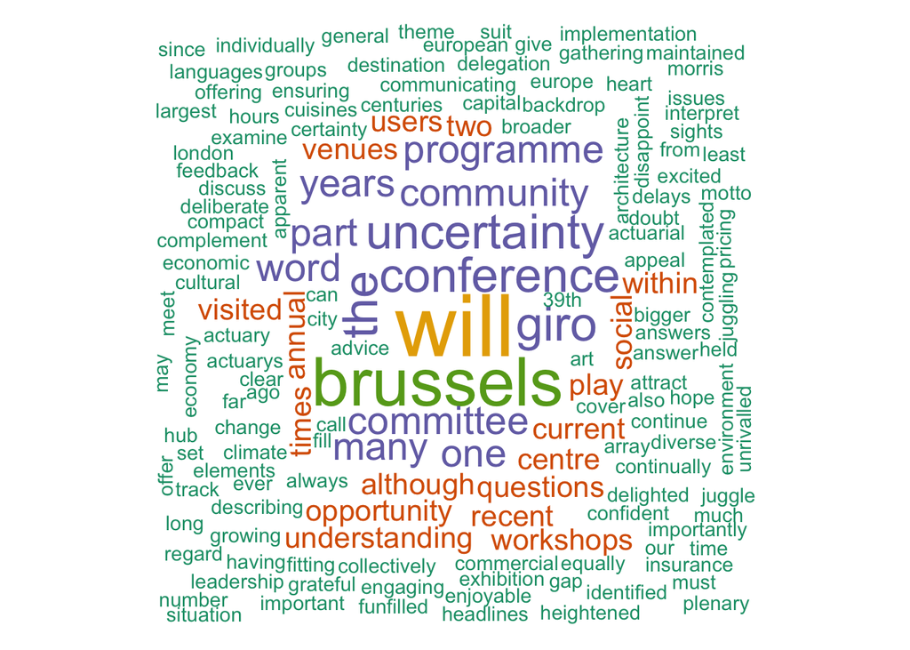

Markus Gesmann, GIRO Brussels, 19 September 2012

# Hello - About me

- Name: [Markus Gesmann](https://plus.google.com/118201313972528070577/posts)
- Profession: Mathematician, working as an analyst at [Lloyd’s](http://www.lloyds.com)
- Maintainer and co-author of two R packages:
  - [ChainLadder](http://code.google.com/p/chainladder/): Statistical methods for the calculation of outstanding claims reserves in general insurance
    - Used by actuaries around the world for reserving and teaching
  - [googleVis](http://code.google.com/p/google-motion-charts-with-r/): Interface between R and the Google Visualisation API
    - Used for data visualisation on www.lloyds.com [(1)](http://www.lloyds.com/the-market/tools-and-resources/resources/statistics-relating-to-lloyds/visualisation), [(2)](http://www.lloyds.com/the-market/tools-and-resources/research/market-intelligence-toolkit/compare-countries)
- Founder and co-organise of the [Cologne R user group](http://www.meetup.com/KoelnRUG/)
- Blogger: [mages’ blog](http://lamges.blogspot.com)

# Agenda

- My motivation for using R
- Brief history of R and its way into insurance
- Three R examples
- R for actuaries: Where to start?
- How I created this presentation with R
- Conclusions and discussion

# Why I started using R

- I started in insurance in 2003, fresh out of university
- I had used a variety of software, tools and languages already
- But I had no experience with spreadsheets
- I was surprised how people worked in insurance
- I was really surprised what colleagues did with spreadsheets
- I looked for alternative data analysis tools
- All the cool kids were talking about R
- I wanted to be cool as well

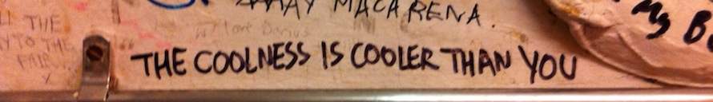

# What is R?

- [R](http://www.r-project.org) is a free software environment for statistical computing and graphics
- It compiles and runs on a wide variety of UNIX platforms, Windows and OS X
- [Notes on the history of R by Pat Burns](http://www.burns-stat.com/pages/Present/infernoishR_annotated.pdf)

# R made its way from academia to industry

- R started at universities in the [1990s](http://www.stat.auckland.ac.nz/~ihaka/downloads/R-paper.pdf)
- It is still largely maintained by academics
- R is widely used for research publications
- [Over 100 text books with R have been published already](http://lamages.blogspot.co.uk/2011/10/r-related-books-traditional-vs-online.html)
- Today many graduates leave universities with some R knowledge

# R made its way from academia to industry

- Many commercial applications support R:
  - [Oracle](http://www.oracle.com/us/corporate/features/features-oracle-r-enterprise-498732.html), [SAP Hana](http://help.sap.com/hana/hana_dev_r_emb_en.pdf), [SAS](http://support.sas.com/rnd/app/studio/Rinterface2.html), [IBM SPSS](http://www-01.ibm.com/software/analytics/spss/products/statistics/developer/), [Spotfire](http://spotfire.tibco.com/~/media/content-center/datasheets/r-splus.ashx), [MS Office](http://www.statconn.com), [QlikView](http://community.qlikview.com/docs/DOC-2975), etc.
- Commercial support is available from third parties, e.g.
  - [Mango Solutions](http://www.mango-solutions.com), [Revolution Analytics](http://www.revolutionanalytics.com), [Trinostics LLC](http://www.trinostics.com), [Burns Stats](http://www.burns-stat.com)
  - Or contact me
- R is established in many disciplines outside academia, e.g. [pharma](http://cran.r-project.org/web/views/ClinicalTrials.html) and [finance](http://cran.r-project.org/web/views/Finance.html)
- The insurance industry is adopting R as well, e.g. [Lloyd’s](https://docs.google.com/open?id=0By35Mtg9R9_RZTk5NzM1NGItYmUzMi00MmQ2LTk0MWYtYTY4YzZiNjg0ODc2)

# Why R in insurance?

- Why Excel, SAS, SQL, SPSS, Minitab, …?
- [John D. Cook](http://www.johndcook.com/blog/): Why and how people use R

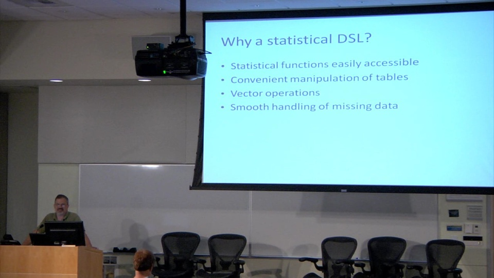

- Because it gets the job done!

# But why use a computing language?

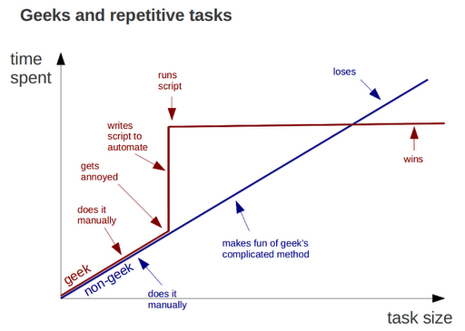

By [Bruno Oliveira](https://plus.google.com/102451193315916178828/posts/MGxauXypb1Y)

# Typical use cases for R in insurance

- Data transformation
- Data analysis
- Statistical modelling
- Prototyping / ad-hoc work
- End user computing
- Background statistical engine for applications, e.g. pricing spreadsheet
- Reporting and reproducible analysis, e.g. MI, Solvency II documentation
- Learning statistical and actuarial skills

# Three R examples

- Reserving: Mack and Bootstrap chain-ladder
- Automated reporting: Create PowerPoint slide with R output
- Extracting data from a web page: Display earth quakes of the last 30 days

# Reserving: Mack chain-ladder

```r
library(ChainLadder) ## load ChainLadder functions
data(GenIns) ## Famous Taylor / Ashe triangle
## For the purpose of the presentation we change the data slightly
dimnames(GenIns)$origin=2002:2011 ## original 1:10
GenIns <- GenIns/1000 ## Requires less space on slide
round(GenIns, 0) ## Display rounded figures
```

```
##       dev
## origin   1    2    3    4    5    6    7    8    9   10
##   2002 358 1125 1735 2218 2746 3320 3466 3606 3834 3901
##   2003 352 1236 2170 3353 3799 4120 4648 4914 5339   NA
##   2004 291 1292 2219 3235 3986 4133 4629 4909   NA   NA
##   2005 311 1419 2195 3757 4030 4382 4588   NA   NA   NA
##   2006 443 1136 2128 2898 3403 3873   NA   NA   NA   NA
##   2007 396 1333 2181 2986 3692   NA   NA   NA   NA   NA
##   2008 441 1288 2420 3483   NA   NA   NA   NA   NA   NA
##   2009 359 1421 2864   NA   NA   NA   NA   NA   NA   NA
##   2010 377 1363   NA   NA   NA   NA   NA   NA   NA   NA
##   2011 344   NA   NA   NA   NA   NA   NA   NA   NA   NA
```

# Reserving: Mack chain-ladder

# Reserving: Mack chain-ladder

```r
M <- MackChainLadder(GenIns, est.sigma="Mack")
M
```

```
## MackChainLadder(Triangle = GenIns, est.sigma = "Mack")
##
##      Latest Dev.To.Date Ultimate    IBNR Mack.S.E CV(IBNR)
## 2002  3,901      1.0000    3,901     0.0      0.0      NaN
## 2003  5,339      0.9826    5,434    94.6     75.5    0.798
## 2004  4,909      0.9127    5,379   469.5    121.7    0.259
## 2005  4,588      0.8661    5,298   709.6    133.5    0.188
## 2006  3,873      0.7973    4,858   984.9    261.4    0.265
## 2007  3,692      0.7223    5,111 1,419.5    411.0    0.290
## 2008  3,483      0.6153    5,661 2,177.6    558.3    0.256
## 2009  2,864      0.4222    6,785 3,920.3    875.3    0.223
## 2010  1,363      0.2416    5,642 4,279.0    971.3    0.227
## 2011    344      0.0692    4,970 4,625.8  1,363.2    0.295
##
##              Totals
## Latest:   34,358.09
## Dev:           0.65
## Ultimate: 53,038.95
## IBNR:     18,680.86
## Mack.S.E   2,447.09
## CV(IBNR):      0.13
```

# Reserving: Mack chain-ladder

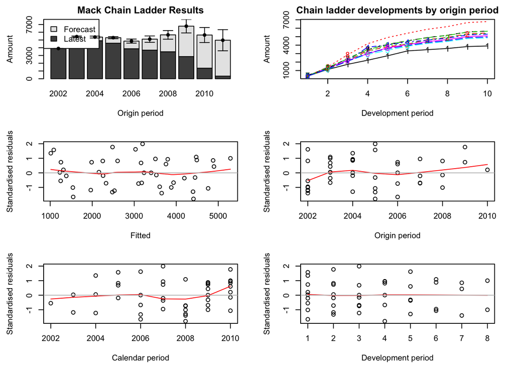

Check for trends in the residuals plots to verify if the Mack-model is reasonable

```r
plot(M) ## Default plot of a Mack chain-ladder output
```

# Reserving: Mack chain-ladder

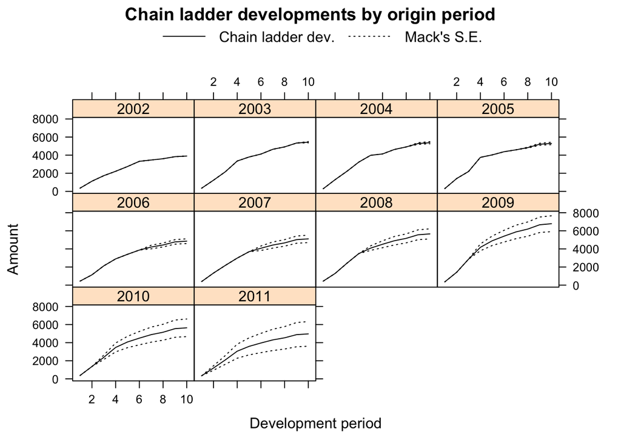

Plot of developments, forecasts and standard errors

```r
plot(M, lattice=TRUE)
```

# Reserving: Bootstrap chain-ladder

```r
B <- BootChainLadder(GenIns, R=999) ## 999 bootstrap replicates
B
```

```
## BootChainLadder(Triangle = GenIns, R = 999)
##
##      Latest Mean Ultimate Mean IBNR IBNR.S.E IBNR 75% IBNR 95%
## 2002  3,901         3,901       0.0        0        0        0
## 2003  5,339         5,435      95.9      114      151      315
## 2004  4,909         5,392     482.7      232      615      911
## 2005  4,588         5,287     698.5      263      867    1,163
## 2006  3,873         4,860     987.2      296    1,183    1,531
## 2007  3,692         5,133   1,441.6      384    1,692    2,091
## 2008  3,483         5,641   2,158.1      473    2,461    2,966
## 2009  2,864         6,840   3,975.2      793    4,466    5,367
## 2010  1,363         5,613   4,249.5    1,055    4,905    6,110
## 2011    344         5,031   4,687.2    2,001    5,817    8,047
##
##                 Totals
## Latest:         34,358
## Mean Ultimate:  53,134
## Mean IBNR:      18,776
## IBNR.S.E         2,861
## Total IBNR 75%: 20,596
## Total IBNR 95%: 23,505
```

# Reserving: Boot chain-ladder

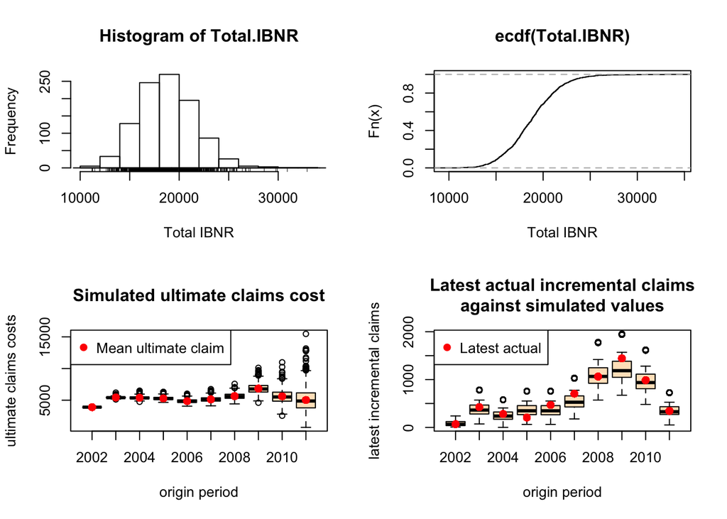

Check if the model is reasonable

```r
plot(B) ## Default plot of a Bootstrap chain-ladder output
```

# Automated reporting: Create PowerPoint slide with R output

```r
myfile=tempfile()
win.metafile(file=myfile)
plot(M, lattice=TRUE)
dev.off()
## Load MS Office interface statconnDCOM
library(rcom)
## Run VBA code from R
ppt<-comCreateObject("Powerpoint.Application")
comSetProperty(ppt,"Visible",TRUE)
myPresColl<-comGetProperty(ppt,"Presentations")
myPres<-comInvoke(myPresColl,"Add")
mySlides<-comGetProperty(myPres,"Slides")
mySlide<-comInvoke(mySlides,"Add",1,12)
myShapes<-comGetProperty(mySlide,"Shapes")
myPicture<-comInvoke(myShapes,"AddPicture",
                     myfile, 0,1,100,10)
```

Check license requirement for commercial use of [statconnDCOM interface](http://www.statconn.com/products.html#pricing).

# Extracting data from a web page

```r
library(XML)
```

```r
library(googleVis)
## Source data diretly from the web
url <- "http://ds.iris.edu/sm2/eventlist/"
eq <- readHTMLTable(readLines(url),
                    colClasses=c("factor", rep("numeric", 4), "factor"))$evTable
names(eq) <- c("DATE", "LAT", "LON", "MAG",
               "DEPTH", "LOCATION_NAME", "IRIS_ID")
##Format location data
eq$loc=paste(eq$LAT, eq$LON, sep=":")
```

# Display earth quake information of last 30 days

```r
library(googleVis)
## Create a geo chart with the Google Chart API
G <- gvisGeoChart(eq, "loc", "DEPTH", "MAG",
                   options=list(displayMode="Markers",
                   colorAxis="{colors:['purple', 'red', 'orange', 'grey']}",
                   backgroundColor="lightblue"), chartid="EQ")
```

```r
plot(G)
```

[output not shown]

# Getting started with R in actuarial work

- [R for Dummies](http://www.dummies.com/store/product/R-For-Dummies.productCd-1119962846.html) by Joris Meys and Andrie de Vries
- [Introduction to R for Actuaries](http://toolkit.pbwiki.com/f/R%20Examples%20for%20Actuaries%20v0.1-1.pdf) by Nigel de Silva
- [Modern actuarial risk theory using R](http://www1.fee.uva.nl/ke/act/people/kaas/ModernART.htm) by Kaas, Goovaerts, Dhaene and Denuit
- [An Interactive Introduction To R](http://www.slideshare.net/dataspora/an-interactive-introduction-to-r-programming-language-for-statistics) by Michael Driscoll and Dan Murphy
- [Formatted Actuarial Vignettes in R](http://www.favir.net/) by Ben Escoto
- [An Actuarial Toolkit](http://www.actuaries.org.uk/system/files/documents/pdf/actuarial-toolkit.pdf) presented at GIRO convention 2006 in Vienna
- [Using R at Lloyd’s](http://lamages.blogspot.co.uk/2011/09/r-and-insurance.html) poster at UseR! conference 2011 in Warwick
- [R-Bloggers](http://wwww.r-bloggers.com)

# R packages for actuaries on CRAN

- [actuar:](http://cran.r-project.org/web/packages/actuar/index.html) Loss distributions modelling, risk theory (including ruin theory), simulation of compound hierarchical models and credibility theory
- [ChainLadder:](http://cran.r-project.org/web/packages/ChainLadder/index.html) Reserving methods in R
- [copula:](http://cran.r-project.org/web/packages/copula/index.html) Multivariate Dependence with Copulas
- [cplm:](http://cran.r-project.org/web/packages/cplm/index.html) Monte Carlo EM algorithms and Bayesian methods for fitting Tweedie compound Poisson linear models
- [evir:](http://cran.r-project.org/web/packages/evir/index.html) Extreme Values in R
- [fitdistrplus:](http://cran.r-project.org/web/packages/fitdistrplus/index.html) Help to fit of a parametric distribution to non-censored or censored data
- [lifecontingencies:](http://cran.r-project.org/web/packages/lifecontingencies/index.html) Package to perform actuarial evaluation of life contingencies
- [lossDev:](http://cran.r-project.org/web/packages/lossDev/index.html) A Bayesian time series loss development model
- [mondate:](http://cran.r-project.org/web/packages/mondate/index.html) R package to keep track of dates in terms of months